# Lab4-team_temp

### Laboratory work 4 - Determining and removing drawbacks of exponential and running mean. Task 2

#### Nikolay Zherdev, Mikhail Kulbeda

#### Skoltech, 10.10.2018

The objective of this laboratory work is to determine conditions for which broadly used methods of running and exponential mean provide effective solution and conditions under which they break down. Important outcome of this exercise is getting skill to choose the most effective method in conditions of uncertainty.

This laboratory work consists of two parts:

I. Comparison of the traditional 13-month running mean with the forward-backward exponential smoothing for approximation of 11-year sunspot cycle.

II. 3d surface filtration using forward-backward smoothing.

## Part 1

### Comparison of the traditional 13-month running mean with the forward-backward exponential smoothing for approximation of 11-year sunspot cycle

Format:

Column 1: year

Column 2: month

Column 3: monthly mean sunspot number

```python
import pandas as pd
import numpy as np
from sklearn.metrics import mean_squared_error
from plotly import __version__
from plotly.offline import download_plotlyjs, init_notebook_mode, plot, iplot
import plotly.graph_objs as go
%matplotlib inline
import matplotlib.pyplot as plt

from matplotlib.pyplot import figure


init_notebook_mode(connected=True)
```

```python
data_path = '/Users/nickzherdev/Desktop/Experimental_Data_Processing/lab4/data_group2.txt'
df = pd.read_csv(data_path, delim_whitespace=True, header=None)
```

```python
n = len(df[0])
day = [1 for i in range(n)] # this is just to make function pd.to_datetime work properly
                            # (it requirs day, month and year minimum)
pd_day = pd.Series(day)

dataframe = pd.DataFrame({
    'Year': df[0],
    'Month': df[1],
    'Sunspot': df[2],
    'Day': pd_day
})

# combining datetime to make smooth plot
date = pd.to_datetime(dataframe[['Year', 'Month', 'Day']])

#df.columns = ['Year', 'Month', 'Sunspot']
```

```python
data = [
    go.Scatter(
        x = date,
        y = df[2],
        name='Sunspot'
    )
]

layout= go.Layout(
    title= 'Solar activity',
    xaxis= dict(
        title= 'date',
    ),
    yaxis=dict(
        title= 'Sunspots',
    ),
    showlegend= True
)
fig= go.Figure(data=data, layout=layout)
iplot(fig)
```

[interactive chart not shown]

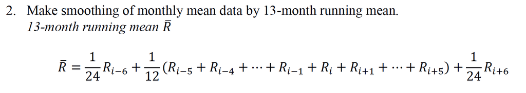

I couldn't manage to apply different weights to rolling function.

```python
running_mean_sunspots = pd.Series(df[2]).rolling(window = 13, center = True).mean()
```

```python
data = [
    go.Scatter(
        x = date,
        y = df[2],
        name='Sunspot'
    ),
    go.Scatter(
        x = date,
        y = running_mean_sunspots,
        name='running mean'
    ),
]

layout= go.Layout(
    title= 'Solar activity',
    xaxis= dict(
        title= 'date',
    ),
    yaxis=dict(
        title= 'Sunspots',
    ),
    showlegend= True
)
fig= go.Figure(data=data, layout=layout)
iplot(fig)
```

[interactive chart not shown]

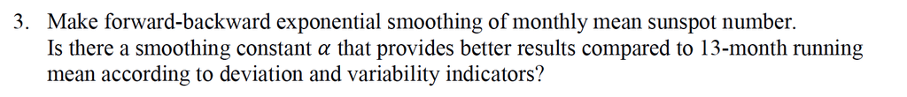

```python
alpha = 0.25
```

```python
def exp_smooth(z, alpha):
    X = np.zeros(z.shape)
    X[0] = z[0]
    for i in range(1, z.shape[0]):
        X[i] = X[i-1] + alpha*(z[i] - X[i-1])
    return X
```

```python
exp_smoothed = exp_smooth(df[2], alpha)
```

```python
def back_exp_smooth(exp_smoothed, alpha):
    B = np.zeros(exp_smoothed.shape[0])
    B[-1] = exp_smoothed[-1]
    for i in reversed(range(exp_smoothed.shape[0]-1)):
        B[i] = B[i+1] + alpha*(exp_smoothed[i] - B[i+1])
    return B
```

```python
def fb_smoothing(msr, alpha):
    exp_smoothed = exp_smooth(msr, alpha)
    return exp_smooth(exp_smoothed[::-1], alpha)[::-1]
```

```python
back_exp_smoothed = back_exp_smooth(exp_smoothed, alpha)
```

```python
data = [
    go.Scatter(
        x = date,
        y = df[2],
        name='Sunspot'
    ),
    go.Scatter(
        x = date,
        y = running_mean_sunspots,
        name='running mean'
    ),
#     go.Scatter(
#         x = date,
#         y = exp_smoothed,
#         name='exp smoothed'
#     ),
    go.Scatter(
        x = date,
        y = back_exp_smoothed,
        name='back exp smoothed'
    ),
]

layout= go.Layout(
    title= 'Solar activity',
    xaxis= dict(
        title= 'date',
    ),
    yaxis=dict(
        title= 'Sunspots',
    ),
    showlegend= True
)
fig= go.Figure(data=data, layout=layout)
iplot(fig)
```

[interactive chart not shown]

```python
def exp_smooth_variability(sequence):
    return np.sum((sequence[2:] - 2*sequence[1:-1] + sequence[:-2])**2)
```

```python
def running_mean_variability(sequence, M):
    X_j2 = sequence[int(M/2)+2:-int(M/2)]
    X_j1 = sequence[int(M/2)+1:-(int(M/2)+1)]
    X_j = sequence[int(M/2):-(int(M/2)+2)]
    RM_variability = np.sum((np.add(np.subtract(X_j2, 2*X_j1), X_j))**2)
    return RM_variability
```

```python
def deviation_indicator(measurments, estimations):
    error = measurments - estimations
    return np.mean(error**2)
```

```python
running_mean_dev_ind = deviation_indicator(df[2], running_mean_sunspots)
back_exp_smooth_dev_ind = deviation_indicator(df[2], back_exp_smoothed)
```

```python
running_mean_dev_ind, back_exp_smooth_dev_ind
```

```
(512.1549184474354, 387.12564371933894)
```

```python
RM_variability = running_mean_variability(running_mean_sunspots, 13)
BES_variability = exp_smooth_variability(back_exp_smoothed)
```

```python
RM_variability, BES_variability
```

```
(3085.5690532544404, 1069.5911783559081)
```

Yes, smoothing constant 𝛼=0.25 provides better results compared to 13-month running mean according to deviation and variability indicators.

## Part 2

### 3d surface filtration using forward-backward smoothing.

The goal of this task is to reconstruct the 3D surface (A) on the basis noisy measurements of the surface (B) in conditions of uncertainty.

Plot noisy and true surface for visualization purposes.

```python
true_path = '/Users/nickzherdev/Desktop/Experimental_Data_Processing/lab4/true_surface.txt'
noise_path = '/Users/nickzherdev/Desktop/Experimental_Data_Processing/lab4/noisy_surface.txt'

df_true = pd.read_csv(true_path, delim_whitespace=True, header=None)
df_noise = pd.read_csv(noise_path, delim_whitespace=True, header=None)
```

```python
data = [
    go.Surface(
        z=df_true.values,
        colorscale='Viridis'
    )


]
layout = go.Layout(
    title='true surface',
    width=800,
    height=700,
    autosize=False,
    margin=dict(
        l=65,
        r=50,
        b=65,
        t=90
    ),
    scene=dict(
        xaxis=dict(
            gridcolor='rgb(255, 255, 255)',
            zerolinecolor='rgb(255, 255, 255)',
            showbackground=True,
            backgroundcolor='rgb(230, 230,230)'
        ),
        yaxis=dict(
            gridcolor='rgb(255, 255, 255)',
            zerolinecolor='rgb(255, 255, 255)',
            showbackground=True,
            backgroundcolor='rgb(230, 230,230)'
        ),
        zaxis=dict(
            gridcolor='rgb(255, 255, 255)',
            zerolinecolor='rgb(255, 255, 255)',
            showbackground=True,
            backgroundcolor='rgb(230, 230,230)'
        ),
        aspectratio = dict( x=1, y=1, z=0.7 ),
        aspectmode = 'manual'
    )
)
fig = go.Figure(data=data, layout=layout)
iplot(fig)
```

[interactive chart not shown]

```python
data = [
    go.Surface(
        z=df_noise.values,
        colorscale='Viridis'
    )


]
layout = go.Layout(
    title='noise surface',
    width=800,
    height=700,
    autosize=False,
    margin=dict(
        l=65,
        r=50,
        b=65,
        t=90
    ),
    scene=dict(
        xaxis=dict(
            gridcolor='rgb(255, 255, 255)',
            zerolinecolor='rgb(255, 255, 255)',
            showbackground=True,
            backgroundcolor='rgb(230, 230,230)'
        ),
        yaxis=dict(
            gridcolor='rgb(255, 255, 255)',
            zerolinecolor='rgb(255, 255, 255)',
            showbackground=True,
            backgroundcolor='rgb(230, 230,230)'
        ),
        zaxis=dict(
            gridcolor='rgb(255, 255, 255)',
            zerolinecolor='rgb(255, 255, 255)',
            showbackground=True,
            backgroundcolor='rgb(230, 230,230)'
        ),
        aspectratio = dict( x=1, y=1, z=0.7 ),
        aspectmode = 'manual'
    )
)
fig = go.Figure(data=data, layout=layout)
iplot(fig)
```

[interactive chart not shown]

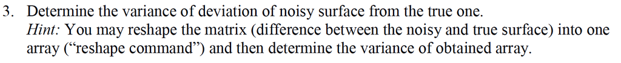

```python
np_df_noise = np.array(df_noise).flatten()
np_df_true = np.array(df_true).flatten()
```

```python
error = np_df_noise - np_df_true
var = np.var(error, ddof = 1)
```

```python
var
```

```
122.05477678749108
```

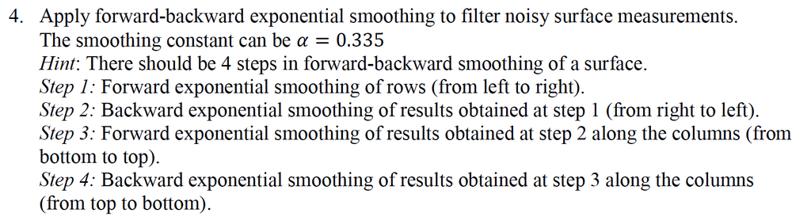

```python
noizy_data = np.loadtxt('/Users/nickzherdev/Desktop/Experimental_Data_Processing/lab4/noisy_surface.txt')
```

```python
def smooth_matrix(_matrix, alpha, smoother=fb_smoothing):

    matrix = _matrix.copy()

    for i in range(len(matrix[1,:])):
        matrix[:,i] = smoother(matrix[:,i], alpha)

    for i in range(len(matrix[:,1])):
        matrix[i,:] = smoother(matrix[i,:], alpha)

    return matrix
```

```python
smoothed_fb = smooth_matrix(noizy_data, 0.335)

data = [
    go.Surface(
        z = smoothed_fb,
        colorscale='Viridis'
    )


]
layout = go.Layout(
    title='noise surface',
    width=800,
    height=700,
    autosize=False,
    margin=dict(
        l=65,
        r=50,
        b=65,
        t=90
    ),
    scene=dict(
        xaxis=dict(
            gridcolor='rgb(255, 255, 255)',
            zerolinecolor='rgb(255, 255, 255)',
            showbackground=True,
            backgroundcolor='rgb(230, 230,230)'
        ),
        yaxis=dict(
            gridcolor='rgb(255, 255, 255)',
            zerolinecolor='rgb(255, 255, 255)',
            showbackground=True,
            backgroundcolor='rgb(230, 230,230)'
        ),
        zaxis=dict(
            gridcolor='rgb(255, 255, 255)',
            zerolinecolor='rgb(255, 255, 255)',
            showbackground=True,
            backgroundcolor='rgb(230, 230,230)'
        ),
        aspectratio = dict( x=1, y=1, z=0.7 ),
        aspectmode = 'manual'
    )
)
fig = go.Figure(data=data, layout=layout)
iplot(fig)
```

[interactive chart not shown]

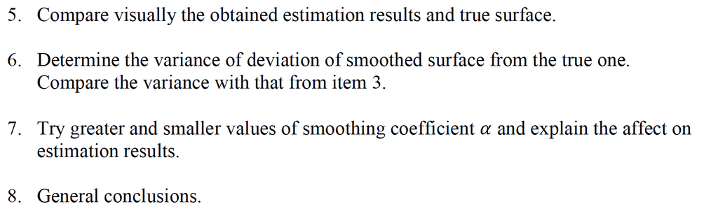

Visually - forward-backward exponential smoothing did a very good job.

```python
estimated = np.array(smoothed_fb).flatten()
np_df_true = np.array(df_true).flatten()
error = estimated - np_df_true
var = np.var(error, ddof = 1)
var
```

```
6.7947501069405565
```

Variance of error between smoothed surface and the true one is 6.79, which is much smaller than in item 3 (122.05).

Now we will compare smoothing effects of small alpha and big alpha.

```python
smoothed_fb_005 = smooth_matrix(noizy_data, 0.05)

data = [
    go.Surface(
        z = smoothed_fb_005,
        colorscale='Viridis'
    ),

]
layout = go.Layout(
    title='noise surface',
    width=800,
    height=700,
    autosize=False,
    margin=dict(
        l=65,
        r=50,
        b=65,
        t=90
    ),
    scene=dict(
        xaxis=dict(
            gridcolor='rgb(255, 255, 255)',
            zerolinecolor='rgb(255, 255, 255)',
            showbackground=True,
            backgroundcolor='rgb(230, 230,230)'
        ),
        yaxis=dict(
            gridcolor='rgb(255, 255, 255)',
            zerolinecolor='rgb(255, 255, 255)',
            showbackground=True,
            backgroundcolor='rgb(230, 230,230)'
        ),
        zaxis=dict(
            gridcolor='rgb(255, 255, 255)',
            zerolinecolor='rgb(255, 255, 255)',
            showbackground=True,
            backgroundcolor='rgb(230, 230,230)'
        ),
        aspectratio = dict( x=1, y=1, z=0.7 ),
        aspectmode = 'manual'
    )
)
fig = go.Figure(data=data, layout=layout)
iplot(fig)
```

[interactive chart not shown]

As we can see from graph, smoothing with alpha = 0.05 produces very "conservative" surface that is not responsible for new measurments.

```python
smoothed_fb_09 = smooth_matrix(noizy_data, 0.9)

data = [
    go.Surface(
        z = smoothed_fb_09,
        colorscale='Viridis'
    )

]
layout = go.Layout(
    title='noise surface',
    width=800,
    height=700,
    autosize=False,
    margin=dict(
        l=65,
        r=50,
        b=65,
        t=90
    ),
    scene=dict(
        xaxis=dict(
            gridcolor='rgb(255, 255, 255)',
            zerolinecolor='rgb(255, 255, 255)',
            showbackground=True,
            backgroundcolor='rgb(230, 230,230)'
        ),
        yaxis=dict(
            gridcolor='rgb(255, 255, 255)',
            zerolinecolor='rgb(255, 255, 255)',
            showbackground=True,
            backgroundcolor='rgb(230, 230,230)'
        ),
        zaxis=dict(
            gridcolor='rgb(255, 255, 255)',
            zerolinecolor='rgb(255, 255, 255)',
            showbackground=True,
            backgroundcolor='rgb(230, 230,230)'
        ),
        aspectratio = dict( x=1, y=1, z=0.7 ),
        aspectmode = 'manual'
    )
)
fig = go.Figure(data=data, layout=layout)
iplot(fig)
```

[interactive chart not shown]

On the contrary, big alpha = 0.9 is very responsible for new measurements and doesn't follow the "history" of estimates, so the produced surface is very noisy.

### General conclusions

Main drawback of forward exponential mean method, the shift, was eliminated in backward exponential mean method. The backward method worked better for processing sunspot number data, but not with all smoothing constants. Optimal smoothing constant 𝛼 should be determined for the method to perform better. Deviation and variability indicators can be used as criteria for a good evaluation method. Also, for finding optimal smoothing constant. Backward exponential mean method can be applied to smooth surface measurements.